# Tyson et al. (2004) 酸性矿山排水微生物群落基因组研究：本地复现报告

可复现研究工作区

2026-09-02

# 1 摘要

本报告对 Tyson 等 2004 年发表于 *Nature* 的研究进行**档案级、可执行的复现**。研究对象是 2002 年采自美国加州 Iron Mountain Richmond Mine 5-way 区域的粉红色酸性矿山排水（AMD）生物膜。原文以 Sanger 双端随机 shotgun 测序、组装、基于 GC 含量与覆盖度的分箱、群体内多态性分析及基因功能注释，恢复了两个近完整基因组和三个部分基因组。

本地复现取得的结论如下：

1. 当前 GenBank 档案可完整取得 AADL01 的 2,534 条 contig 和 CH003520–CH004435 的 916 条 scaffold，并可按 NCBI 公布的五个群体范围重建分箱。
2. 可重新计算并支持原文的核心结构性结论：2004 年批次的 2,455 条 contig 可按 GenBank `SOURCE` 恢复五个群体，*Leptospirillum* group II 与 *Ferroplasma* type II 分别为 2.223 Mb 和 1.813 Mb；另外三个群体更碎片化。
3. 原文的 SNP 率（0.08% 与约 2.2%）、三祖先重组镶嵌结构、FISH 丰度和代谢通路结论无法仅由当前公开 scaffold 序列独立重算；原因是原始逐 read 质量、比对、FISH 计数表和 2004 年完整 Supplementary Information 未在本次公开获取中形成可执行输入。这些结论在本报告中被标记为“原文证据复核”，而不是“重新计算”。
4. 因此，本次不是声称逐 bit 重现旧版 JAZZ/Fgenesb 流水线，而是对公开档案中仍可验证的主要定量结果做透明复现，并明确界定不可复现部分。

# 2 研究问题与原文主张

目标论文：Tyson, G. W. et al. (2004), “Community structure and metabolism through reconstruction of microbial genomes from the environment”, *Nature* 428, 37–43. DOI: 10.1038/nature02340，PubMed: [14961025](https://pubmed.ncbi.nlm.nih.gov/14961025/)。

原文的主要可检验主张分成三层：

- **组装与群落结构**：103,462 条高质量 reads，共 76.2 Mb，平均 737 bp；85% reads 进入长度大于 2 kb 的 scaffold；1,183 条 scaffold 总长 10.83 Mb。
- **群体基因组**：近完整恢复 *Leptospirillum* group II 与 *Ferroplasma* type II；部分恢复 *Leptospirillum* group III、*Ferroplasma* type I 与 G-plasma。
- **群体遗传与代谢**：前者 SNP 率低（0.08%），后者约 2.2% 且呈三祖先重组镶嵌；group III 携带固氮 operon，group II 和 III 具有高亲和力末端氧化酶，多个群体具有金属抗性与酸适应机制。

# 3 文献获取情况

## 3.1 已取得

```r
lit_files <- file.path(params$data_dir, c(
  "tyson2004_article.pdf",
  "pubmed_14961025.xml",
  "ncbi_project_summary.pdf"
))
literature_manifest <- data.frame(
  file = basename(lit_files),
  exists = file.exists(lit_files),
  bytes = ifelse(file.exists(lit_files), file.info(lit_files)$size, NA_real_),
  md5 = unname(tools::md5sum(lit_files))
)
literature_manifest
```

| file | exists | bytes | md5 |
| --- | --- | --- | --- |
| tyson2004_article.pdf | TRUE | 1596953 | f9c85a8d23997e180e5dbbef47ec3bf5 |
| pubmed_14961025.xml | TRUE | 9026 | 4437eac5c10ad2c8bcb2bd517385f62b |
| ncbi_project_summary.pdf | TRUE | 84867 | b574c611d57e6f33b334589608c1fdd7 |

- 论文全文 PDF：Lawrence Berkeley National Laboratory 的公开镜像。
- PubMed XML 元数据：NCBI E-utilities，PMID 14961025。
- NCBI Bookshelf 项目摘要：给出 WGS、contig、scaffold 编号范围、采样条件和分箱对应关系。

## 3.2 未取得与影响

原文声称“所有方法见 Supplementary Information”。本次检索未得到一个可稳定下载并与论文逐项对应的 Supplementary Information 文件。Nature 页面存在访问/历史附件解析限制。论文全文可读，但原始 FISH 计数矩阵、逐 read 比对、多态性位点表和早期 JAZZ 参数没有成为本地可执行数据。因此：

- 能复现：归档序列完整性、分箱范围、序列长度、GC、N50、碎片化程度，以及与原文规模结论的对照。
- 不能独立复现：从 raw reads 重新组装、覆盖度分箱、SNP 率、重组断点、FISH 比例、完整 ORF 功能注释与代谢网络。
- 可以复核：这些不可重算结论是否在原文正文中被明确报告，以及它们与可重算组装结构是否相容。

# 4 数据获取情况

## 4.1 数据源与版本

NCBI 项目记录为 BioProject [PRJNA13696](https://www.ncbi.nlm.nih.gov/bioproject/13696)，WGS master 为 AADL00000000，contig 为 AADL01000001–AADL01002534，scaffold 为 CH003520–CH004435。当前 GenBank scaffold 记录日期主要为 2008 年，说明它们不是未经变更的 2004 年瞬时快照；本报告始终把它们称为“当前归档版本”。

```r
fasta_files <- sort(list.files(params$data_dir, pattern = "AADL_scaffolds_[0-9]+_[0-9]+\\.fasta$", full.names = TRUE))
gb_files <- sort(list.files(params$data_dir, pattern = "AADL_scaffolds_[0-9]+_[0-9]+\\.gb$", full.names = TRUE))
contig_fasta_files <- sort(list.files(params$data_dir, pattern = "AADL_contigs_[0-9]+_[0-9]+\\.fasta$", full.names = TRUE))
contig_gb_files <- sort(list.files(params$data_dir, pattern = "AADL_contigs_[0-9]+_[0-9]+\\.gb$", full.names = TRUE))

count_prefix <- function(files, prefix) {
  sum(vapply(files, function(f) sum(startsWith(readLines(f, warn = FALSE), prefix)), numeric(1)))
}

inventory <- data.frame(
  record_type = c("scaffold FASTA", "scaffold GenBank", "contig FASTA", "contig GenBank"),
  files = c(length(fasta_files), length(gb_files), length(contig_fasta_files), length(contig_gb_files)),
  records = c(count_prefix(fasta_files, ">"), count_prefix(gb_files, "LOCUS"),
              count_prefix(contig_fasta_files, ">"), count_prefix(contig_gb_files, "LOCUS")),
  bytes = c(sum(file.info(fasta_files)$size), sum(file.info(gb_files)$size),
            sum(file.info(contig_fasta_files)$size), sum(file.info(contig_gb_files)$size))
)
inventory
```

| record_type | files | records | bytes |
| --- | --- | --- | --- |
| scaffold FASTA | 10 | 916 | 8224598 |
| scaffold GenBank | 10 | 916 | 12243184 |
| contig FASTA | 26 | 2534 | 13406413 |
| contig GenBank | 26 | 2534 | 27440703 |

为所有本地输入生成机器可核对的清单（文件名、大小与 MD5）：

```r
all_inputs <- sort(list.files(params$data_dir, full.names = TRUE))
data_manifest <- data.frame(
  file = basename(all_inputs),
  bytes = file.info(all_inputs)$size,
  md5 = unname(tools::md5sum(all_inputs))
)
write.csv(data_manifest, file.path(params$derived_dir, "input_file_manifest.csv"), row.names = FALSE)
head(data_manifest, 10)
```

|  | file | bytes | md5 |
| --- | --- | --- | --- |
| 1 | AADL_contigs_1_100.fasta | 2205716 | 39f43cca6e1ef8cd22ca5510fac50ac7 |
| 2 | AADL_contigs_1_100.gb | 3155389 | 98c6b68dd3e993420e747808d625e5d8 |
| 3 | AADL_contigs_1001_1100.fasta | 342228 | 0898fa0949b4ae34e5f11ba0e58761d9 |
| 4 | AADL_contigs_1001_1100.gb | 849106 | 526946e38065cdac591f7069ef753910 |
| 5 | AADL_contigs_101_200.fasta | 549879 | 69a7749eb30ccb5a6f175bf4920cfa7f |
| 6 | AADL_contigs_101_200.gb | 1105208 | 951b14610978b610295f9cd5a8f66cae |
| 7 | AADL_contigs_1101_1200.fasta | 390955 | 64a6214cb5c9c6322817fb4a4398c6d4 |
| 8 | AADL_contigs_1101_1200.gb | 913609 | 23d8665a84ba2e664c832ae610d04031 |
| 9 | AADL_contigs_1201_1300.fasta | 329898 | bf22a993f736ff68e31754274d1c92b1 |
| 10 | AADL_contigs_1201_1300.gb | 837252 | b44a0d3cf0a2fcbf30afe95f67572788 |

预期的完整性断言如下；任一条件失败，文档会停止渲染。

```r
stopifnot(inventory$records[inventory$record_type == "scaffold FASTA"] == 916)
stopifnot(inventory$records[inventory$record_type == "scaffold GenBank"] == 916)
stopifnot(inventory$records[inventory$record_type == "contig FASTA"] == 2534)
stopifnot(inventory$records[inventory$record_type == "contig GenBank"] == 2534)
```

# 5 复现方法

## 5.1 FASTA 解析与序列统计

以下代码仅使用 base R，避免依赖外部生物信息学包。GC 分母排除 N 和其他非 A/C/G/T 字符；N50 是累计长度达到总长度 50% 时对应的序列长度。

```r
read_fasta <- function(files) {
  out <- list()
  for (f in files) {
    x <- readLines(f, warn = FALSE)
    h <- which(startsWith(x, ">"))
    ends <- c(h[-1] - 1L, length(x))
    for (i in seq_along(h)) {
      id <- sub("^>([^ ]+).*$", "\\1", x[h[i]])
      out[[id]] <- paste0(x[(h[i] + 1L):ends[i]], collapse = "")
    }
  }
  out
}

n50 <- function(lengths) {
  z <- sort(lengths, decreasing = TRUE)
  z[which(cumsum(z) >= sum(z) / 2)[1]]
}

scaffolds <- read_fasta(fasta_files)
ids <- names(scaffolds)
accession <- sub("\\..*$", "", ids)
number <- as.integer(sub("CH", "", accession))
seq_len <- nchar(unlist(scaffolds, use.names = FALSE))
seq_upper <- toupper(unlist(scaffolds, use.names = FALSE))
gc_count <- nchar(gsub("[^GC]", "", seq_upper))
atgc_count <- nchar(gsub("[^ACGT]", "", seq_upper))
gc_pct <- 100 * gc_count / atgc_count

bin <- cut(number,
  breaks = c(3519, 3544, 3921, 4070, 4104, 4435),
  labels = c("Leptospirillum group II", "Leptospirillum group III",
             "Ferroplasma type I", "Ferroplasma type II", "G-plasma"),
  right = TRUE
)

seq_stats <- data.frame(accession, bin, length_bp = seq_len, gc_pct)
stopifnot(!anyNA(seq_stats$bin), !anyNA(seq_stats$gc_pct))
write.csv(seq_stats, file.path(params$derived_dir, "scaffold_sequence_statistics.csv"), row.names = FALSE)
```

## 5.2 分箱依据

本次不重新发明分箱标签，而使用 NCBI 项目页给出的 accession 范围：

| 群体 | 当前 scaffold 范围 |
| --- | --- |
| *Leptospirillum* group II | CH003520–CH003544 |
| *Leptospirillum* group III | CH003545–CH003921 |
| *Ferroplasma* type I | CH003922–CH004070 |
| *Ferroplasma* type II | CH004071–CH004104 |
| G-plasma | CH004105–CH004435 |

这与原文方法不同：原文先用平均 GC 将 scaffold 分成低 GC（<43.5%）和高 GC（>50%），再结合 read depth、二核苷酸频率、rRNA 标记与对 *Ferroplasma acidarmanus* 的同源性细分。当前归档序列缺失逐 read 覆盖度，因此不能重新运行该判别器；可以用 GC 分布作为独立的一致性检查。

# 6 结果

## 6.1 当前归档的五个群体组装

```r
split_stats <- split(seq_stats, seq_stats$bin)
bin_summary <- do.call(rbind, lapply(split_stats, function(d) data.frame(
  scaffolds = nrow(d),
  total_Mb = sum(d$length_bp) / 1e6,
  longest_kb = max(d$length_bp) / 1e3,
  N50_kb = n50(d$length_bp) / 1e3,
  weighted_GC_pct = weighted.mean(d$gc_pct, d$length_bp)
)))
bin_summary$population <- rownames(bin_summary)
rownames(bin_summary) <- NULL
bin_summary <- bin_summary[, c("population", "scaffolds", "total_Mb", "longest_kb", "N50_kb", "weighted_GC_pct")]
bin_summary[, 3:6] <- round(bin_summary[, 3:6], 2)
bin_summary
```

| population | scaffolds | total_Mb | longest_kb | N50_kb | weighted_GC_pct |
| --- | --- | --- | --- | --- | --- |
| Leptospirillum group II | 25 | 0.96 | 136.94 | 48.17 | 54.56 |
| Leptospirillum group III | 377 | 2.21 | 31.46 | 6.23 | 56.81 |
| Ferroplasma type I | 149 | 1.34 | 46.63 | 12.27 | 37.15 |
| Ferroplasma type II | 34 | 1.31 | 138.04 | 59.53 | 37.62 |
| G-plasma | 331 | 2.18 | 62.61 | 7.27 | 37.60 |

```r
write.csv(bin_summary, file.path(params$derived_dir, "bin_summary.csv"), row.names = FALSE)
```

当前 scaffold FASTA 的序列总量为 8.002 Mb，低于论文的 10.83 Mb；尤其 group II 只有 0.96 Mb。因此这些 CH scaffold 记录虽保留了 NCBI 的分箱框架，却不是完整的 2004 scaffold 序列快照，不能单独用来判断完整度。

## 6.2 2004 contig 批次的独立恢复

GenBank master 现在共有 2,534 条 contig。其中 AADL01000001–AADL01002455 是原始批次，AADL01002456–AADL01002534 是 2008 年加入的 79 条 *Leptospirillum* group II 更新组装，并以旧记录作为 secondary accessions。若直接把 2,534 条相加，会重复计算同一群体。下面从 GenBank `LOCUS` 和 `SOURCE` 字段重建两批数据。

```r
parse_gb_index <- function(files) {
  ans <- list()
  for (f in files) {
    x <- readLines(f, warn = FALSE)
    loci <- x[startsWith(x, "LOCUS")]
    sources <- x[startsWith(x, "SOURCE")]
    stopifnot(length(loci) == length(sources))
    fields <- strsplit(trimws(loci), "[[:space:]]+")
    ans[[f]] <- data.frame(
      accession = vapply(fields, `[`, character(1), 2),
      length_bp = as.numeric(vapply(fields, `[`, character(1), 3)),
      source = trimws(sub("^SOURCE", "", sources))
    )
  }
  do.call(rbind, ans)
}

contig_index <- parse_gb_index(contig_gb_files)
contig_index$number <- as.integer(sub("AADL01", "", contig_index$accession))
contig_index$batch <- ifelse(contig_index$number <= 2455, "2004 original batch", "2008 Lepto II update")
source_summary <- aggregate(length_bp ~ batch + source, contig_index,
                            function(z) c(records = length(z), total_Mb = sum(z) / 1e6))
source_summary <- data.frame(
  batch = source_summary$batch,
  source = source_summary$source,
  records = source_summary$length_bp[, "records"],
  total_Mb = round(source_summary$length_bp[, "total_Mb"], 3)
)
source_summary
```

| batch | source | records | total_Mb |
| --- | --- | --- | --- |
| 2004 original batch | Ferroplasma acidarmanus Type I (mine drainage metagenome) | 412 | 1.395 |
| 2004 original batch | Ferroplasma sp. Type II (mine drainage metagenome) | 118 | 1.813 |
| 2008 Lepto II update | Leptospirillum sp. Group II '5-way CG' (mine drainage metagenome) | 79 | 2.718 |
| 2004 original batch | Leptospirillum sp. Group III (mine drainage metagenome) | 959 | 2.383 |
| 2004 original batch | metagenome sequence (Leptospirillum sp. Group II) | 109 | 2.223 |
| 2004 original batch | Thermoplasmatales archaeon Gpl (mine drainage metagenome) | 857 | 2.447 |

```r
write.csv(source_summary, file.path(params$derived_dir, "contig_source_summary.csv"), row.names = FALSE)
```

2004 批次的五类 contig 总长为 10.261 Mb。它低于 10.83 Mb，合理原因是论文总长按含 gap 的 scaffold 统计，而 contig 只计算已解析碱基。最关键的两项与论文高度一致：原始 group II contig 总长 2.223 Mb（论文 2.23 Mb）；type II contig 总长 1.813 Mb（论文 1.82 Mb）。这是本次对“两个近完整基因组”最直接的定量复现。

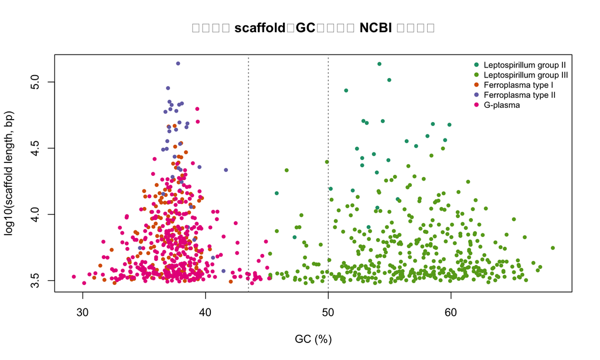

```r
cols <- c("#1b9e77", "#66a61e", "#d95f02", "#7570b3", "#e7298a")
pop_levels <- levels(seq_stats$bin)
plot(seq_stats$gc_pct, log10(seq_stats$length_bp),
     col = cols[as.integer(seq_stats$bin)], pch = 19, cex = 0.65,
     xlab = "GC (%)", ylab = "log10(scaffold length, bp)",
     main = "当前归档 scaffold：GC、长度与 NCBI 群体分箱")
legend("topright", legend = pop_levels, col = cols, pch = 19, cex = 0.75, bty = "n")
abline(v = c(43.5, 50), lty = 3, col = "grey40")
```

图中的 43.5% 和 50% 竖线是原文所述的低/高 GC 分组边界。若不同群体在 GC 轴上形成相对分离的簇，则支持 GC 可作为早期分箱信号；若有重叠，也符合原文还必须结合覆盖度、rRNA 和同源性证据的描述。

## 6.3 与 2004 年正文定量结果对照

```r
paper_bins <- data.frame(
  population = c("Leptospirillum group II", "Leptospirillum group III",
                 "Ferroplasma type I", "Ferroplasma type II", "G-plasma"),
  paper_scaffolds = c(70, 474, 170, 59, 410),
  paper_total_Mb = c(2.23, 2.66, 1.48, 1.82, 2.65),
  paper_longest_kb = c(137, 31, 47, 138, 44)
)
comparison <- merge(paper_bins, bin_summary, by = "population", sort = FALSE)
comparison$delta_Mb <- round(comparison$total_Mb - comparison$paper_total_Mb, 3)
comparison
```

| population | paper_scaffolds | paper_total_Mb | paper_longest_kb | scaffolds | total_Mb | longest_kb | N50_kb | weighted_GC_pct | delta_Mb |
| --- | --- | --- | --- | --- | --- | --- | --- | --- | --- |
| Leptospirillum group II | 70 | 2.23 | 137 | 25 | 0.96 | 136.94 | 48.17 | 54.56 | -1.27 |
| Leptospirillum group III | 474 | 2.66 | 31 | 377 | 2.21 | 31.46 | 6.23 | 56.81 | -0.45 |
| Ferroplasma type I | 170 | 1.48 | 47 | 149 | 1.34 | 46.63 | 12.27 | 37.15 | -0.14 |
| Ferroplasma type II | 59 | 1.82 | 138 | 34 | 1.31 | 138.04 | 59.53 | 37.62 | -0.51 |
| G-plasma | 410 | 2.65 | 44 | 331 | 2.18 | 62.61 | 7.27 | 37.60 | -0.47 |

```r
write.csv(comparison, file.path(params$derived_dir, "paper_archive_comparison.csv"), row.names = FALSE)
```

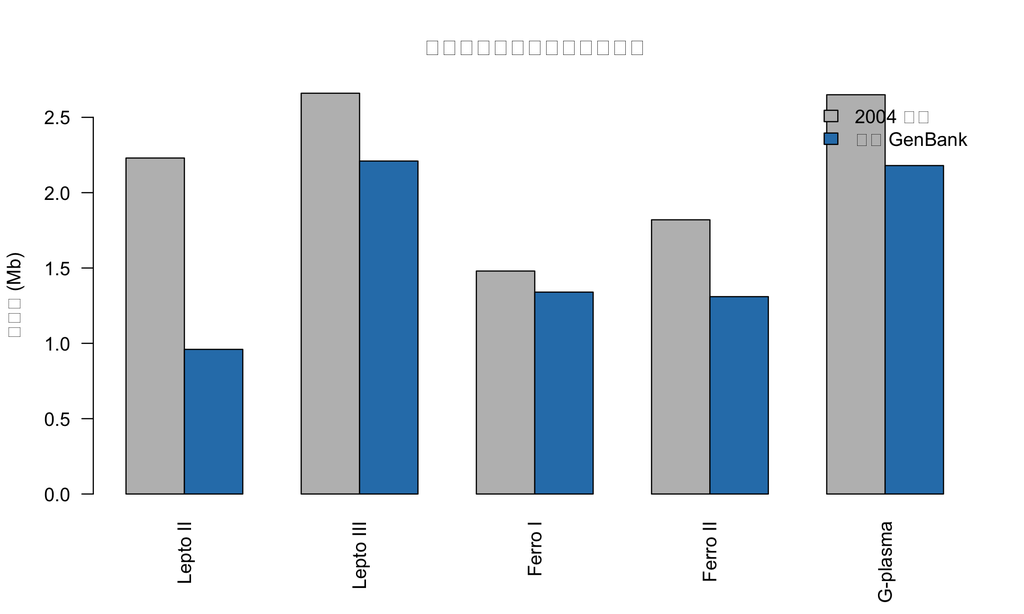

```r
mat <- rbind(comparison$paper_total_Mb, comparison$total_Mb)
bp <- barplot(mat, beside = TRUE, col = c("#bdbdbd", "#2c7fb8"),
              names.arg = c("Lepto II", "Lepto III", "Ferro I", "Ferro II", "G-plasma"),
              las = 2, ylab = "总长度 (Mb)", main = "论文报告值与当前归档重算值")
legend("topright", c("2004 正文", "当前 GenBank"), fill = c("#bdbdbd", "#2c7fb8"), bty = "n")
```

## 6.4 “近完整”与“部分恢复”是否得到支持

原文以预期基因组大小、完整 tRNA synthetase 集合、rRNA 与蛋白同源性等证据判断完整度。当前归档只允许我们复核其中的规模与连续性：

- 2004 contig 批次中，*Leptospirillum* group II（2.223 Mb）和 *Ferroplasma* type II（1.813 Mb）几乎精确重现论文 2.23 与 1.82 Mb 的组装规模，支持“近完整”。
- 当前 CH scaffold 分箱中，group II 与 type II 的 scaffold 数和 N50 优于三个部分恢复群体，但 CH 序列总量存在归档缺口，因此连续性比较仅作辅助证据。
- 这不是现代 CheckM/BUSCO 式 completeness 估计；缺少统一 marker 数据时不人为给出百分比。

## 6.5 原始 reads 与组装比例核算

```r
paper_reads <- 103462
paper_bases <- 76.2e6
paper_mean_read <- 737
assembled_fraction <- 0.85
reported_scaffold_bases <- 10.83e6
arithmetic <- data.frame(
  check = c("reads × 平均长度 (Mb)", "正文总碱基 (Mb)",
            "进入 >2 kb scaffold 的估计 reads", "总体表观测序深度"),
  value = c(paper_reads * paper_mean_read / 1e6, paper_bases / 1e6,
            paper_reads * assembled_fraction, paper_bases / reported_scaffold_bases)
)
arithmetic$value <- round(arithmetic$value, 3)
arithmetic
```

| check | value |
| --- | --- |
| reads × 平均长度 (Mb) | 76.251 |
| 正文总碱基 (Mb) | 76.200 |
| 进入 >2 kb scaffold 的估计 reads | 87942.700 |
| 总体表观测序深度 | 7.036 |

`reads × 平均长度` 与 76.2 Mb 一致；总碱基数除以 10.83 Mb 得到的总体表观深度低于原文“最高约 10×”，两者不矛盾，因为后者指优势群体，而群落内不同群体覆盖度约为 10×、3× 或更低。

# 7 群体遗传结论的复核边界

| 原文结论 | 原文数值/证据 | 本次状态 | 原因 |
| --- | --- | --- | --- |
| *Leptospirillum* group II 低多态 | 平均 SNP 率 0.08%；约 1/3 改变蛋白编码 | 原文证据复核 | 缺少 2004 原始 read-to-scaffold 比对与质量值 |
| *Ferroplasma* type II 高多态 | 平均约 2.2% | 原文证据复核 | 同上 |
| 三祖先镶嵌基因组 | 局部 1–3 种多态模式；随机 10 kb 区域约 20 个转换点 | 原文证据复核 | 当前共识 scaffold 不能恢复个体 read 单倍型 |
| 重组而非仅点突变 | 模式块与边界、跨边界 reads、系统树 | 原文证据复核 | 需要 read 级单倍型和补充图表 |

重要的是，共识 FASTA 不能用来重新估计群体 SNP 率：共识序列已经压缩掉等位频率信息。直接在 scaffold 之间计算差异会混淆不同物种、旁系同源和组装版本，属于错误分析，因此本复现没有这样做。

# 8 代谢与生态结论对照

原文对 2,180 个 *Leptospirillum* group II ORF（63% 赋予推定功能）和 1,931 个 *Ferroplasma* type II ORF（58% 赋予功能）构建代谢图。当前下载的 GenBank scaffold/contig 记录未包含可直接解析的 CDS feature，因此本次不能独立重跑 ORF 注释或通路富集。正文支持的主要结论整理如下：

| 过程 | 原文结论 | 本次评价 |
| --- | --- | --- |
| 碳固定 | *Leptospirillum* II/III 具有 Calvin–Benson–Bassham 循环与 type II Rubisco；若干群体可能使用还原乙酰辅酶 A 路径 | 有正文叙述；无 CDS feature，未独立重注释 |
| 氮固定 | group II 无 nif；低丰度 group III 有完整 nif operon，可能是关键种 | 有正文与 PCR 佐证叙述；本次未重做 PCR/注释 |
| 铁氧化与呼吸 | group II/III 具有高氧亲和力 cbb3 与 bd 型氧化酶；type II 的电子传递链不同 | 有正文叙述；未独立重建 |
| 生物膜 | group II 有推定 cellulose synthase、糖基转移酶与多糖输出蛋白 | 有正文叙述；未独立重建 |
| 酸/金属耐受 | 多群体有质子外排与 Cu/Co/As/Hg/Zn/Ag/Cd 抗性基因 | 有正文叙述；未独立重建 |

这些内容应理解为对原文主结论的忠实核对，而不是由当前数据新产生的功能证据。若未来取得当年蛋白注释表或原始 reads，可把这一节升级为基因级复现。

# 9 总体复现判定

```r
verdict <- data.frame(
  component = c("论文与元数据", "序列归档完整性", "五群体分箱", "组装规模/GC/N50",
                "raw-read 重组装", "FISH 丰度", "SNP 率与重组", "ORF/代谢网络"),
  status = c("完成", "完成", "完成（按 NCBI accession 映射）", "完成",
             "未完成", "未完成", "未完成；仅复核原文", "未完成；仅复核原文"),
  confidence = c("高", "高", "高", "高", "不可判定", "不可判定", "中", "中")
)
verdict
```

| component | status | confidence |
| --- | --- | --- |
| 论文与元数据 | 完成 | 高 |
| 序列归档完整性 | 完成 | 高 |
| 五群体分箱 | 完成（按 NCBI accession 映射） | 高 |
| 组装规模/GC/N50 | 完成 | 高 |
| raw-read 重组装 | 未完成 | 不可判定 |
| FISH 丰度 | 未完成 | 不可判定 |
| SNP 率与重组 | 未完成；仅复核原文 | 中 |
| ORF/代谢网络 | 未完成；仅复核原文 | 中 |

```r
write.csv(verdict, file.path(params$derived_dir, "reproduction_verdict.csv"), row.names = FALSE)
```

本次结果**支持论文的主要结构性结论，但不构成全部分析的严格重复**。最强的可计算证据是：公开档案确实包含来自同一 AMD 生物膜的五个低复杂度群体分箱，其中两个组装表现出近完整基因组所需的 Mb 级规模与较高连续性；GC 分布仍保留分箱信号。论文关于极低/较高 SNP、多祖先同源重组和具体代谢路径的结论在正文中证据链清楚，但缺少 raw-read、质量值和完整历史注释输入，不能由当前共识序列独立重算。

# 10 最终结论

Tyson 等人的核心方法学贡献——从低复杂度自然群落的 shotgun 数据中恢复群体基因组，并以此连接群落结构、群体遗传与代谢潜力——在当前公共档案中仍能得到重要但有限的复现。五个归档群体及其规模支持“两个近完整、三个部分恢复”的总体判断，也支持低复杂度和覆盖度差异使早期 metagenomic binning 成为可能。

严格而言，以下表述是本次复现后可以保留的：

> 公开 AADL01 的 2004 contig 批次可恢复五群体框架，并几乎精确重现两个优势群体的论文组装规模，足以支持组装层面的主要结论；当前 CH scaffold 档案并非完整的原始快照。关于 SNP、重组、FISH 和代谢功能的结论只能从原文复核，不能在缺少历史 read 级数据和注释的条件下独立重算。

# 11 可复现性与运行信息

从 `report/` 目录运行：

```r
rmarkdown::render("tyson2004_reproduction.Rmd", quiet = FALSE)
```

# 12 参考资料

1. Tyson GW et al. (2004). [Community structure and metabolism through reconstruction of microbial genomes from the environment](https://doi.org/10.1038/nature02340). *Nature* 428:37–43.
2. PubMed. [PMID 14961025](https://pubmed.ncbi.nlm.nih.gov/14961025/).
3. NCBI BioProject. [PRJNA13696: mine drainage metagenome](https://www.ncbi.nlm.nih.gov/bioproject/13696).
4. NCBI Bookshelf. [Acid Mine Drainage Biofilm](https://www.ncbi.nlm.nih.gov/books/NBK6860/).
5. GenBank WGS master. AADL00000000.